# Reproducible Research: Peer Assessment 1

Supiwat Sakthanakul

## Loading and preprocessing the data

Reading the data from the working directory.

```r
data <- read.csv("activity.csv", header = TRUE, sep = ",")
```

## What is mean total number of steps taken per day?

In this first part we ignore the NA values inside the dataset, the mean and median values were calculated from the dataset.

```r
## Subseting the data of steps taken/day
totalstep.day <- aggregate(steps ~ date, data, sum)
totalstep.day
```

```
##          date steps
## 1  2012-10-02   126
## 2  2012-10-03 11352
## 3  2012-10-04 12116
## 4  2012-10-05 13294
## 5  2012-10-06 15420
## 6  2012-10-07 11015
## 7  2012-10-09 12811
## 8  2012-10-10  9900
## 9  2012-10-11 10304
## 10 2012-10-12 17382
## 11 2012-10-13 12426
## 12 2012-10-14 15098
## 13 2012-10-15 10139
## 14 2012-10-16 15084
```

[output cut: 39 more lines]

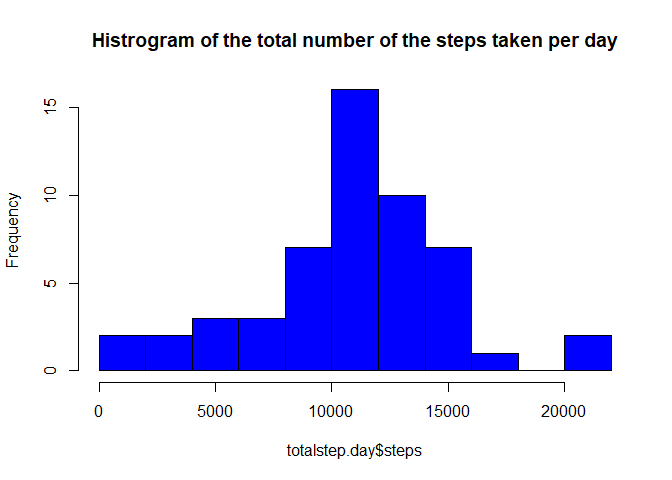

```r
hist(totalstep.day$steps, breaks=10, main = "Histrogram of the total number of the steps taken per day",
     col = "Blue")
```

```r
Mean <- mean(totalstep.day$steps)
Median <- median(totalstep.day$steps)
results <- cbind(Mean, Median)
print(results)
```

```
##          Mean Median
## [1,] 10766.19  10765
```

## What is the average daily activity pattern?

In this section we calculate and report the highest number of mean of 5-min interval, the time series illustrated the peak at the same value from the calculated function.

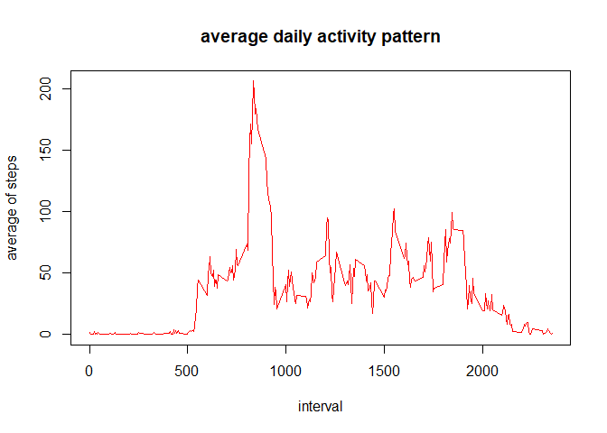

```r
#Calculate the mean using the interval function as indicator
na.data <- na.omit(data)
avg <- na.data %>%
  group_by(interval) %>%
  summarize(Mean_Value = mean(steps))


plot((avg$interval), avg$Mean_Value, type='l',
     xlab="interval", ylab="average of steps",
     main='average daily activity pattern',
     col = "red")
```

```r
avg$interval[which.max(avg$Mean_Value)]
```

```
## [1] 835
```

```r
avg$Mean_Value[which.max(avg$Mean_Value)]
```

```
## [1] 206.1698
```

## Imputing missing values

```r
#Count the NA values in the dataset
num.na <- sum(is.na(data))
num.na
```

```
## [1] 2304
```

```r
#Replace the NA values with mean
newdata <- read.csv("activity.csv", header = TRUE, sep = ",")
newdata$steps[is.na(newdata$steps)] <-  mean(na.omit(newdata$steps))

totalstep.day <- aggregate(steps ~ date, newdata, sum)
totalstep.day
```

```
##          date    steps
## 1  2012-10-01 10766.19
## 2  2012-10-02   126.00
## 3  2012-10-03 11352.00
## 4  2012-10-04 12116.00
## 5  2012-10-05 13294.00
## 6  2012-10-06 15420.00
## 7  2012-10-07 11015.00
## 8  2012-10-08 10766.19
## 9  2012-10-09 12811.00
## 10 2012-10-10  9900.00
## 11 2012-10-11 10304.00
## 12 2012-10-12 17382.00
## 13 2012-10-13 12426.00
## 14 2012-10-14 15098.00
```

[output cut: 47 more lines]

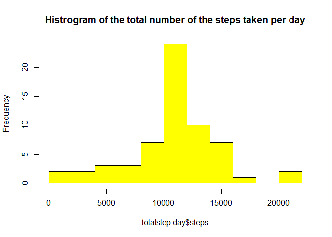

```r
hist(totalstep.day$steps, breaks=10, main = "Histrogram of the total number of the steps taken per day",
     col = "Yellow")
```

```r
Mean <- mean(totalstep.day$steps)
Median <- median(totalstep.day$steps)
results <- cbind(Mean, Median) ## The mean and the median remain the same value as the original dataset
print(results)
```

```
##          Mean   Median
## [1,] 10766.19 10766.19
```

## Are there differences in activity patterns between weekdays and weekends?

In this section we introduce the new variables to the dataset which we named “weekends”, and the variable has values in “weekdays” or “weekends” that correspond to the dates provided from the original dataset.

```r
data$date <- as.POSIXlt(data$date)

#Create new variable
data$weekends <- NA
data$dates <- weekdays(data$date)

#Identify weekends and weekdays
data$weekends <- ifelse(weekdays(data$date) %in% c("Saturday", "Sunday"), "Weekend", "Weekday")
data$weekends <- factor(data$weekends)

#Subsetting the data to weekend and weekday
Weekend <- data[data$weekends == "Weekend", ]
Weekday <- data[data$weekends == "Weekday", ]


#Calculate the mean using the Weekend
weekdayMean <- aggregate(steps ~ interval, Weekday, mean)
weekendMean <- aggregate(steps ~ interval, Weekend, mean)
```

The time series plots were compared the difference between the number of average steps per day during the weekdays and the weekends.

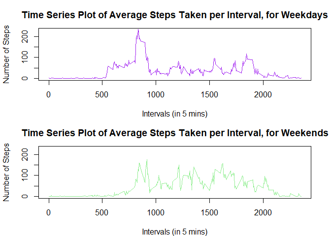

```r
par(mfrow=c(2, 1), mar=c(4, 4.1, 3, 2.1))
plot((weekdayMean$interval), weekdayMean$steps, type="l",
     main="Time Series Plot of Average Steps Taken per Interval, for Weekdays",
     xlab="Intervals (in 5 mins)", ylab="Number of Steps",
     col="Purple", lwd=1.5, ylim=c(0, 230))
plot((weekendMean$interval), weekendMean$steps, type="l",
     main="Time Series Plot of Average Steps Taken per Interval, for Weekends",
     xlab="Intervals (in 5 mins)", ylab="Number of Steps",
     col="lightgreen", lwd=1.5, ylim=c(0, 230))
```